# SleepHealth

Siva

2023-10-17

## Sleep Health and Lifestyle Data Analysis

### Data Overview

The sleep health and lifestyle dataset is imported from Kaggle https://www.kaggle.com/datasets/uom190346a/sleep-health-and-lifestyle-dataset The Sleep Health and Lifestyle Dataset 374 records of 13 variables, that are associated with sleep and daily routines. It observes details such as gender, age, occupation, sleep duration, quality of sleep, physical activity level, stress levels, BMI category, blood pressure, heart rate, daily steps, and sleep disorders if any.

## Including libraries

```r
library(readr)
library(tidyverse)
```

```r
library(ggplot2)
library(corrplot)
library(leaps)
library(MASS)
library(readxl)
```

## Import the data

```r
shls <- read_xlsx("/Users/siva/Documents/Sleep_HLS/Data/shls.xlsx")
head(shls)
```

```
## # A tibble: 6 × 13
##   `Person ID` Gender   Age Occupation          `Sleep Duration` `Quality of Sl…`
##         <dbl> <chr>  <dbl> <chr>                          <dbl>            <dbl>
## 1           1 Male      27 Software Engineer                6.1                6
## 2           2 Male      28 Doctor                           6.2                6
## 3           3 Male      28 Doctor                           6.2                6
## 4           4 Male      28 Sales Representati…              5.9                4
## 5           5 Male      28 Sales Representati…              5.9                4
## 6           6 Male      28 Software Engineer                5.9                4
## # … with 7 more variables: `Physical Activity Level` <dbl>,
## #   `Stress Level` <dbl>, `BMI Category` <chr>, `Blood Pressure` <chr>,
## #   `Heart Rate` <dbl>, `Daily Steps` <dbl>, `Sleep Disorder` <chr>
```

```r
names(shls)
```

```
##  [1] "Person ID"               "Gender"
##  [3] "Age"                     "Occupation"
##  [5] "Sleep Duration"          "Quality of Sleep"
##  [7] "Physical Activity Level" "Stress Level"
##  [9] "BMI Category"            "Blood Pressure"
## [11] "Heart Rate"              "Daily Steps"
## [13] "Sleep Disorder"
```

## Summary of data

```r
summary(shls)
```

```
##    Person ID         Gender               Age         Occupation
##  Min.   :  1.00   Length:374         Min.   :27.00   Length:374
##  1st Qu.: 94.25   Class :character   1st Qu.:35.25   Class :character
##  Median :187.50   Mode  :character   Median :43.00   Mode  :character
##  Mean   :187.50                      Mean   :42.18
##  3rd Qu.:280.75                      3rd Qu.:50.00
##  Max.   :374.00                      Max.   :59.00
##  Sleep Duration  Quality of Sleep Physical Activity Level  Stress Level
##  Min.   :5.800   Min.   :4.000    Min.   :30.00           Min.   :3.000
##  1st Qu.:6.400   1st Qu.:6.000    1st Qu.:45.00           1st Qu.:4.000
##  Median :7.200   Median :7.000    Median :60.00           Median :5.000
##  Mean   :7.132   Mean   :7.313    Mean   :59.17           Mean   :5.385
##  3rd Qu.:7.800   3rd Qu.:8.000    3rd Qu.:75.00           3rd Qu.:7.000
##  Max.   :8.500   Max.   :9.000    Max.   :90.00           Max.   :8.000
##  BMI Category       Blood Pressure       Heart Rate     Daily Steps
##  Length:374         Length:374         Min.   :65.00   Min.   : 3000
##  Class :character   Class :character   1st Qu.:68.00   1st Qu.: 5600
##  Mode  :character   Mode  :character   Median :70.00   Median : 7000
##                                        Mean   :70.17   Mean   : 6817
##                                        3rd Qu.:72.00   3rd Qu.: 8000
##                                        Max.   :86.00   Max.   :10000
##  Sleep Disorder
##  Length:374
##  Class :character
##  Mode  :character
##
##
##
```

## Renaming columns

```r
colnames(shls)[5] ="Sleep_Duration"
colnames(shls)[6] ="Quality_of_Sleep"
colnames(shls)[7] ="Phys_Activity"
colnames(shls)[8] ="Stress_Level"
colnames(shls)[9] ="BMI_type"
colnames(shls)[10] ="BP"
colnames(shls)[11] ="Heart_rate"
colnames(shls)[12] ="Daily_steps"
colnames(shls)[13] ="Sleep_Disorder"
```

## Bar chart of Quality of sleep

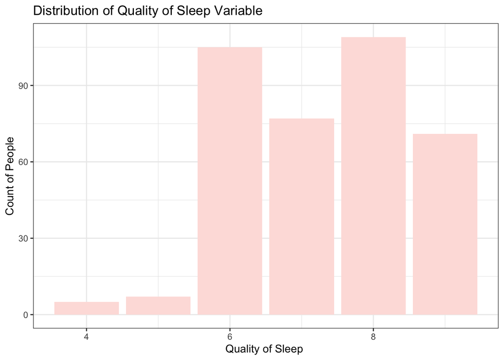

## Catagorical Variables

```r
table(shls$Gender)
```

```
##
## Female   Male
##    185    189
```

```r
table(shls$Occupation)
```

```
##
##           Accountant               Doctor             Engineer
##                   37                   71                   63
##               Lawyer              Manager                Nurse
##                   47                    1                   73
## Sales Representative          Salesperson            Scientist
##                    2                   32                    4
##    Software Engineer              Teacher
##                    4                   40
```

```r
table(shls$BMI_type)
```

```
##
##        Normal Normal Weight         Obese    Overweight
##           195            21            10           148
```

```r
table(shls$Sleep_Disorder)
```

```
##
##    Insomnia        None Sleep Apnea
##          77         219          78
```

## Correlation Matrix

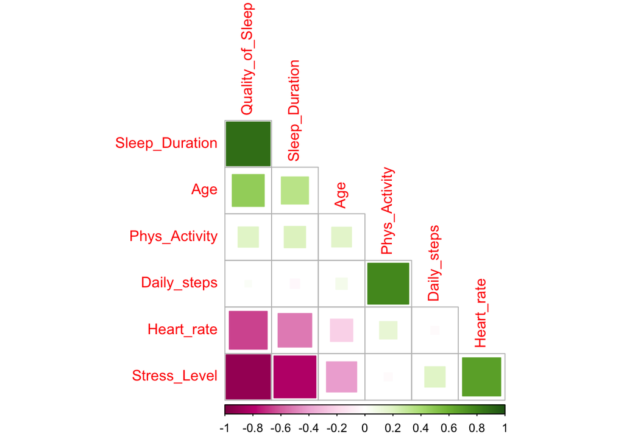

```r
num_cols = subset(shls,select=c(3,5,6,7,8,11,12))
res = round(cor(num_cols),2)
corrplot(res, method = 'square', order = 'FPC', type = 'lower', diag = FALSE,col = COL2('PiYG'))
```

## Linear Regression Analysis

```r
qs = lm(Quality_of_Sleep ~ Age+Sleep_Duration+Phys_Activity+Stress_Level+Heart_rate+Daily_steps, data=shls)

summary(qs)
```

```
##
## Call:
## lm(formula = Quality_of_Sleep ~ Age + Sleep_Duration + Phys_Activity +
##     Stress_Level + Heart_rate + Daily_steps, data = shls)
##
## Residuals:
##      Min       1Q   Median       3Q      Max
## -1.10171 -0.22599  0.00457  0.22990  0.96768
##
## Coefficients:
##                  Estimate Std. Error t value Pr(>|t|)
## (Intercept)     5.289e+00  6.917e-01   7.646 1.84e-13 ***
## Age             1.415e-02  2.447e-03   5.781 1.59e-08 ***
## Sleep_Duration  6.388e-01  4.309e-02  14.827  < 2e-16 ***
## Phys_Activity  -6.777e-04  2.023e-03  -0.335 0.737865
## Stress_Level   -3.157e-01  2.499e-02 -12.633  < 2e-16 ***
## Heart_rate     -2.850e-02  8.292e-03  -3.437 0.000655 ***
## Daily_steps     8.968e-05  2.579e-05   3.477 0.000568 ***
## ---
## Signif. codes:  0 '***' 0.001 '**' 0.01 '*' 0.05 '.' 0.1 ' ' 1
##
## Residual standard error: 0.3638 on 367 degrees of freedom
## Multiple R-squared:  0.9091, Adjusted R-squared:  0.9076
## F-statistic: 611.7 on 6 and 367 DF,  p-value: < 2.2e-16
```

Keeping quality of sleep variable as the response and other numerical columns such as age, sleep duration, physical activity, stress level, heart rate and daily steps as features multiple linear regression model was built. On observing the summary of this model physical activity variable is found to be statistically insignificant. Age, sleep duration and daily steps positively impacts quality of sleep, while stress level and heart rate impacts quality of sleep negatively. So let’s drop physical activity in the next model.

```r
qs_pa = update(qs,.~.-Phys_Activity)
summary(qs_pa)
```

```
##
## Call:
## lm(formula = Quality_of_Sleep ~ Age + Sleep_Duration + Stress_Level +
##     Heart_rate + Daily_steps, data = shls)
##
## Residuals:
##      Min       1Q   Median       3Q      Max
## -1.10058 -0.22554  0.00356  0.24143  0.96563
##
## Coefficients:
##                  Estimate Std. Error t value Pr(>|t|)
## (Intercept)     5.438e+00  5.284e-01  10.291  < 2e-16 ***
## Age             1.412e-02  2.442e-03   5.779 1.60e-08 ***
## Sleep_Duration  6.350e-01  4.149e-02  15.305  < 2e-16 ***
## Stress_Level   -3.129e-01  2.345e-02 -13.345  < 2e-16 ***
## Heart_rate     -3.028e-02  6.361e-03  -4.761 2.78e-06 ***
## Daily_steps     8.215e-05  1.261e-05   6.514 2.41e-10 ***
## ---
## Signif. codes:  0 '***' 0.001 '**' 0.01 '*' 0.05 '.' 0.1 ' ' 1
##
## Residual standard error: 0.3634 on 368 degrees of freedom
## Multiple R-squared:  0.9091, Adjusted R-squared:  0.9078
## F-statistic: 735.8 on 5 and 368 DF,  p-value: < 2.2e-16
```

## Finding the best model

```r
library(leaps)
reg = regsubsets(Quality_of_Sleep ~ Age+Sleep_Duration+ Phys_Activity+Stress_Level+Heart_rate+Daily_steps, data=shls)
n=dim(shls)[1]
rs = summary(reg)
rs$which
```

```
##   (Intercept)   Age Sleep_Duration Phys_Activity Stress_Level Heart_rate
## 1        TRUE FALSE          FALSE         FALSE         TRUE      FALSE
## 2        TRUE FALSE           TRUE         FALSE         TRUE      FALSE
## 3        TRUE FALSE           TRUE         FALSE         TRUE      FALSE
## 4        TRUE  TRUE           TRUE         FALSE         TRUE      FALSE
## 5        TRUE  TRUE           TRUE         FALSE         TRUE       TRUE
## 6        TRUE  TRUE           TRUE          TRUE         TRUE       TRUE
##   Daily_steps
## 1       FALSE
## 2       FALSE
## 3        TRUE
## 4        TRUE
## 5        TRUE
## 6        TRUE
```

## AIC, BIC and Adjusted R Squared Plot

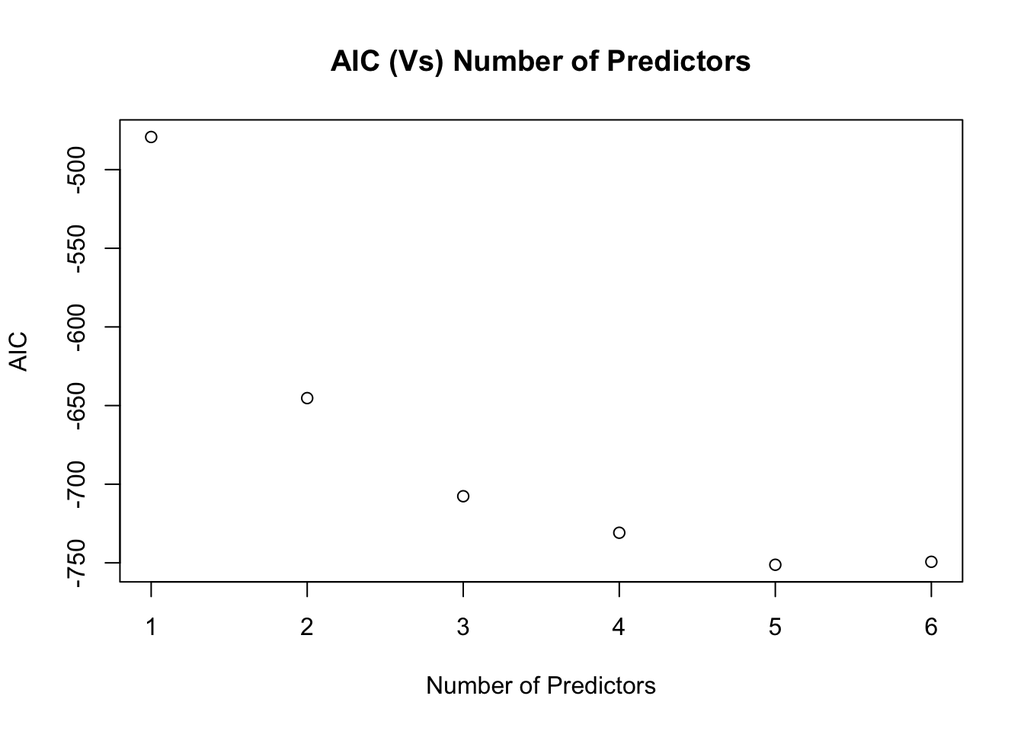

```r
AIC = 2*(2:7)+n*log(rs$rss/n)
plot(1:6,AIC,xlab='Number of Predictors',ylab='AIC', main='AIC (Vs) Number of Predictors')
```

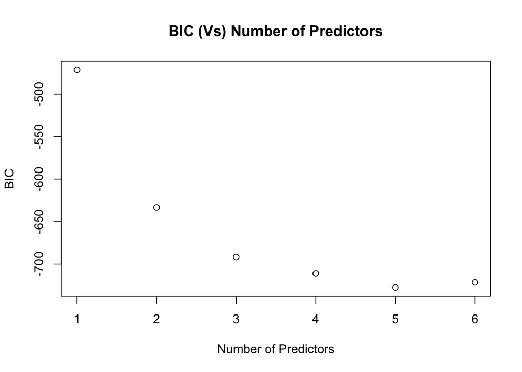

```r
BIC = log(n)*(2:7)+n*log(rs$rss/n)
plot(1:6,BIC,xlab='Number of Predictors',ylab='BIC', main='BIC (Vs) Number of Predictors')
```

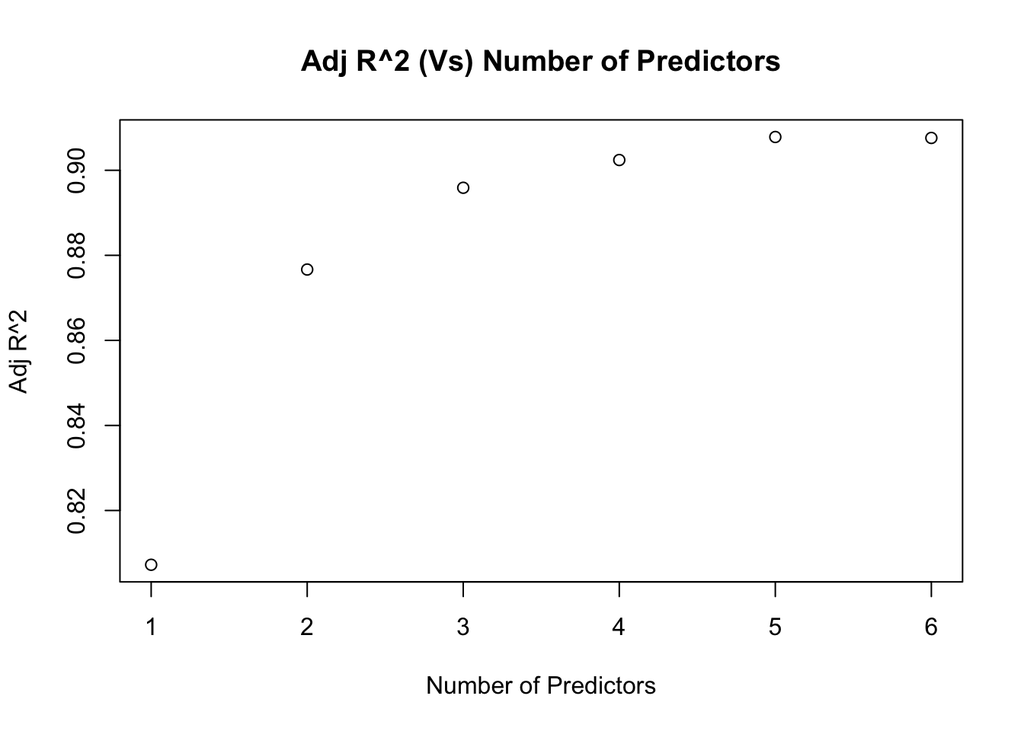

```r
plot(1:6,rs$adjr2,xlab='Number of Predictors',ylab='Adj R^2', main='Adj R^2 (Vs) Number of Predictors')
```